# An AI-assisted self-building protest database

ISSR LUNCHTIME SEMINER

Johannes B. Gruber (GESIS); Corinna Hertweck (U Zürich); Marius Sältzer (U Oldenburg)

2026-09-17

## Acknowledgement of Country

The University of Queensland (UQ) acknowledges the Traditional Owners and their custodianship of the lands on which we meet.

We pay our respects to their Ancestors and their descendants, who continue cultural and spiritual connections to Country.

We recognise their valuable contributions to Australian and global society.

[figure not shown]

*Image: Digital reproduction of A guidance through time by Casey Coolwell and Kyra Mancktelow*

## Why a new protest database?

- Currently, no centralized database of protests in Germany
- Different sources of information:
  - Newspaper coverage
  - Social media
  - Flyers
  - etc.
- Centralized DB would be valuable!

⟶ public, journalists & researchers

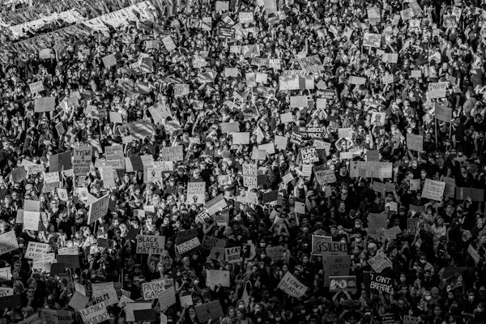

[Teemu Paananen](https://unsplash.com/@xteemu) via unsplash.com

### Questions on protests

- How do police respond to different types of protests?
- Can we track specific movements (e.g., Fridays for Future) and see their growth or spread?
- How do slogans, messaging or framing vary within a movement over time or across regions?

### Questions on reporting

- Are certain outlets systematically over- or underreporting?
- How does the media report on/frame (different) protests?
- Can we derive a quantification of media bias from the reporting on crowd sizes?

[figure not shown]

## Data Pipeline

## Overview

### Step 1

FreshRSS…

- … retrieves 74 RSS feeds of German newspapers…
- … puts title, content blurb, author and **URL** in PostgreSQL database…

… every 10 minutes

### Step 1.5

Helper script…

- … filters for `"protest|demonstr"` in title, text, and tags
- … copies data to AmCAT (Elasticsearch with user access control)

### Step 2

Paperboy:

1. retrieves URLs from AmCAT
2. downloads full HTML from news site
3. parses out headline, author, full article text
4. saves results to AmCAT (updates entries)

[`paperboy`: R package with custom parsers for 182 news sites; monitored daily]

### Step 3

A local **qwen3.5:9b** model (via Ollama) classifies each event.

- Zero-shot classification
- Runs fully offline — no API calls, no costs
- Output: structured JSON labels -> AmCAT

### Step 4

Public dashboard:

- all variables visible for everyone – except full texts
- news articles and variables fully searchable
- aggregation of variables as plots or csv

[figure not shown]

## Dashboard

- [`is_protest`](https://protest.jbgruber.online/projects/de-news/dashboard?tab=summary&query=NrDeCIEcFcFMCcCe4Bc4CWBnA%2BgB3gPYAusmRKR8c4AvgDQQwLJpZ6ElkoBmAhgDaZYtALp0AdtH78RQA)
- [`police_present`](https://protest.jbgruber.online/projects/de-news/dashboard?tab=summary&query=NrDeCIEcFcFMCcCe4Bc4AOB7ANgSwMawD668sAzrAHYAuKN8c4AvgDQQwLJpZ6EllKtFADMAhtkosAuqyrRs2aUA)
- [`protester_violence`](https://protest.jbgruber.online/projects/de-news/dashboard?tab=summary&query=NrDeCIEcFcFMCcCe4Bc4AO8D2AXWBnPeAfQDcBLLAG1gDsBjWY%2BWdLePAExR3jnAC%2BAGggwEyNJlwEiZSjQZMWbDrG4AzAIZV8sQQF0htaFSr6gA)
- [`sentiment`](https://protest.jbgruber.online/projects/de-news/dashboard?tab=aggregate&query=NrC6BoG8CIEMDt4HsAusUFMAm0BcMA3WAGwFcMBnPYaARwHcN4BmAOgFZcBOAI2lAC%2BA0EA)
- [`target`](https://protest.jbgruber.online/projects/de-news/dashboard?tab=aggregate&query=NrC6BoG8CIEMDt4HsAusUFMAm0BcMA3WAGwFcMBnPYaARwHcN4BmAOgFZcBOAI2lAC%2BA0EA)
- [`protest_size_text`](https://protest.jbgruber.online/projects/de-news/dashboard?tab=aggregate&query=NrC6BoG8CIEMDt4HsAusUFMAm0BcMA3WAGwFcMBnPYaARwHcN4BmAOgFZcBOAI2lAC%2BA0EA)
- [`protest_size_numeric`](https://protest.jbgruber.online/projects/de-news/dashboard?tab=aggregate&query=NrC6BoG8CIEMDt4HsAusUFMAm0BcMA3WAGwFcMBnPYaARwHcN4BmAOgFZcBOAI2lAC%2BA0EA)

## Validation (Preliminary!)

[figure not shown]

**Caution**

Based on only 25 documents annotated by 1 coder

## Estimation of Truth: The Bayesian Framework

## The Issue

**Sources Disagree!**

- For example, crowd size:
  - Police systematically **under-report**
  - Organizers systematically **over-report**
  - Ideological outlets **selectively** distort
- Traditional fix: expert triangulation → not scalable at our data volumes

**Our approach:** estimate the *latent true size* and *source reliability* **simultaneously**

→ Bayesian epistemology applied to source credibility

(Yin et al. 2007; Zhao et al. 2012; Weidmann and Rød 2015)

## The Generative Model

**How does a source arrive at a number?**

Start from the **true size**, then each source applies its own *habit*:

1. a **systematic bias** — does it tend to over- or under-count? (police ÷2, organizers ×3)
2. some **random noise** — how consistent is it from event to event?

We work with **log** numbers, because bias is *multiplicative*:

> “twice as many” — not “+500 people”

So “police report half” and “organizers report triple” become simple **shifts** up or down.

$$\underbrace{\log y_{i,s}}_{\text{what we read}} = \underbrace{\log z_i}_{\text{true size}} + \underbrace{\beta_s}_{\text{source's bias}} + \underbrace{\text{noise}}_{\text{consistency } \sigma_s}$$

## Two unknowns, one loop

**Chicken-and-egg:** to find the *true size* we’d need to know *which sources to trust* — but to know which sources to trust, we’d need the true size.

**The way out — bootstrap it:**

1. Start with the plain **median** of the reports as a rough truth
2. Score each source by how far it usually lands from that truth → **credibility**
3. Re-estimate the truth, now letting **credible sources count more**
4. Repeat until it stops moving

**Credible** = small bias **and** consistent.

We combine sources with a **weighted median**, so one wildly exaggerated report can’t drag the estimate — robust by design.

→ credible sources shape the consensus; the consensus reveals who’s credible

## Does it work? A simulation

We build a **fake world where we know the truth**, hide it, and check whether the model recovers it.

**Setup**

- 120 events, 18 sources
- Each source gets a *true* bias & consistency we assign
- Each event gets a *true* size
- Sources cover events *selectively* (aligned outlets cover their own side more)

Then: throw away the truth, run the model, compare.

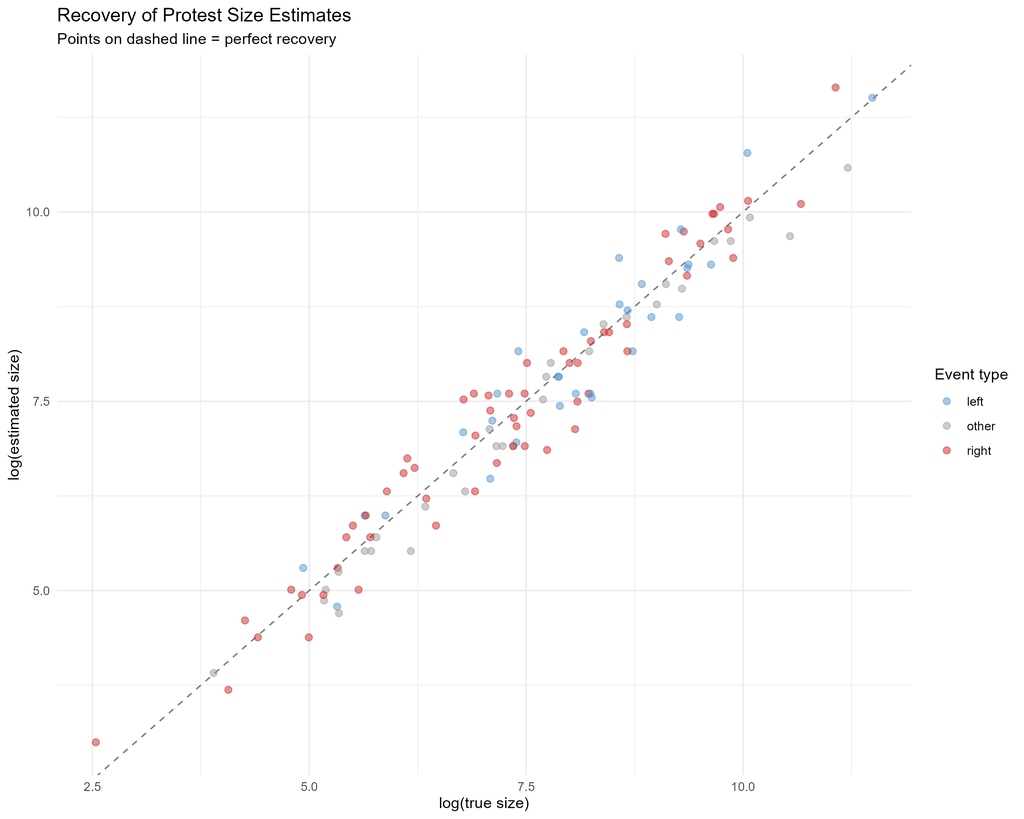

## Does it work? Recovering the sources

The model also recovers **who** the biased sources are — not just the crowd sizes.

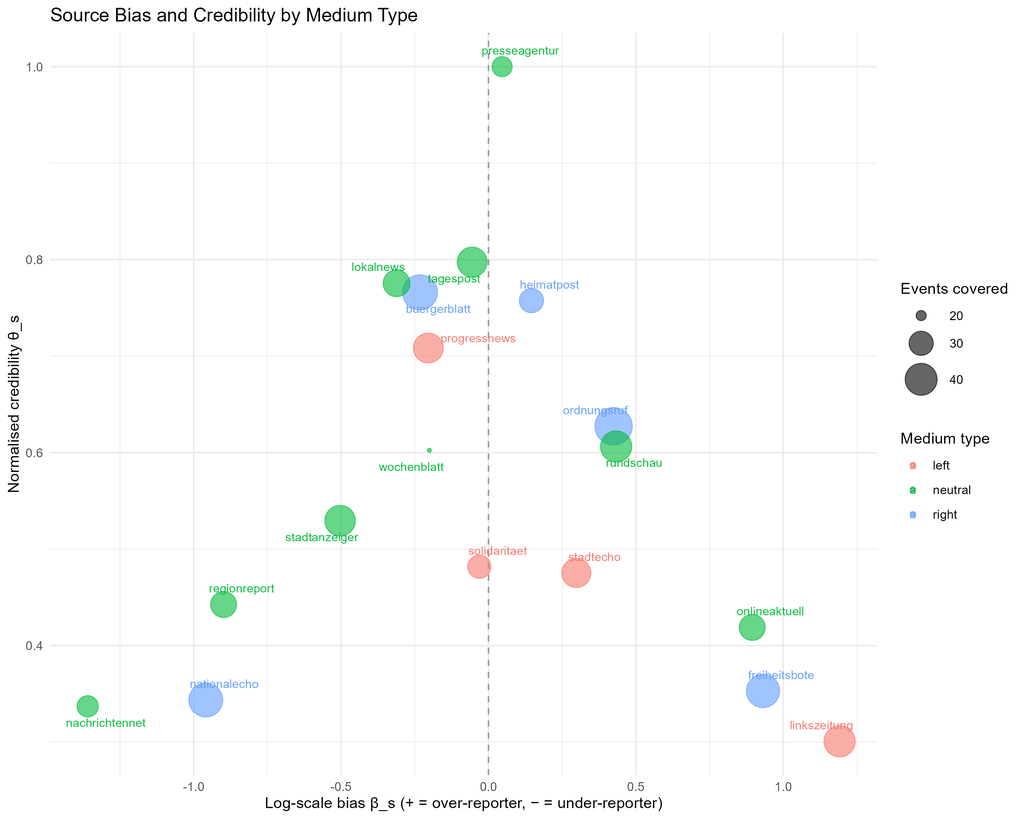

- Each dot is a news source
- **x** = estimated bias (left = under-reports, right = over-reports)
- **y** = estimated credibility
- The model rediscovers the biases we planted:

| recovered vs. true | correlation |
| --- | --- |
| source bias $\beta_s$ | **0.98** |
| ideological skew | **0.95** |

## From Articles to Protests

- So far, we have data on the article level
- We do not yet know which articles describe the same event
- To compare what differs and how, we need data on the event level

**Article level** (what we have)

| article_id | source | date | location | protest_size_numeric |
| --- | --- | --- | --- | --- |
| 1 | Tagesschau | 2026-03-14 | Berlin | 15,000 |
| 2 | Bild | 2026-03-14 | Berlin | 8,000 |
| 3 | taz | 2026-03-21 | Leipzig | 2,500 |
| … | … | … | … | … |
| n | Spiegel | 2026-03-21 | Leipzig | 3,000 |

**Event level** (what we need)

| event_id | article_ids | date | location |
| --- | --- | --- | --- |
| 1 | 1, 2 | 2026-03-14 | Berlin |
| 2 | 3, …, n | 2026-03-21 | Leipzig |

## Solution: Model Context Protocol

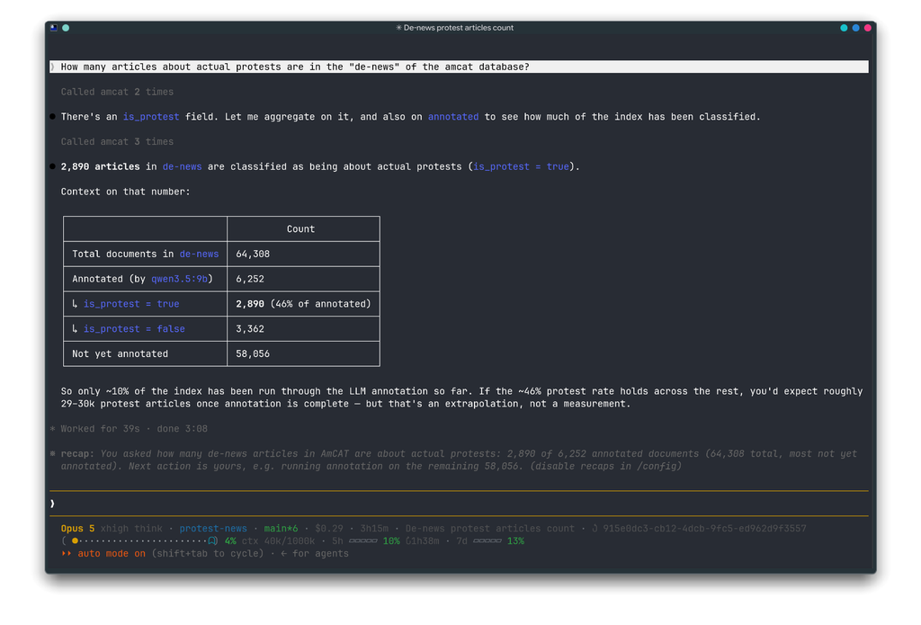

## Strategy for Articles to Events

- Event = date × city × issue; nationwide days of action become several city events linked as one campaign.
- New articles are first matched to existing events (same region, ±3 days); only unmatched ones create a new event.
- New events snowball: search city + issue keywords, then slogans, organisations, venues; window −3/+10 days, max 8 queries.

## Summary

### Data

- All parts are available as reproducible docker container
- No costs, except for compute
- Automatically growing dataset
- Dashboard linked in repo

[figure not shown]

### Model

- Estimates *true* protest size **and** source reliability jointly
- Credibility learned from disagreement – no hand-labelling
- Robust to outliers (weighted median) & multiplicative bias (log scale)
- Simulation: recovers sizes and source bias ($r \approx 0.98$)
- By-product: a data-driven measure of **media bias**

# Questions | Comments?

# References

Weidmann, Nils B, and Espen Geelmuyden Rød. 2015. “Making Uncertainty Explicit.” *Journal of Peace Research* 52 (1): 125–28. https://doi.org/10.1177/0022343314523807.

Yin, Xiaoxin, Jiawei Han, and Philip S. Yu. 2007. “Truth Discovery with Multiple Conflicting Information Providers on the Web.” *Proceedings of the 13th ACM SIGKDD International Conference on Knowledge Discovery and Data Mining* (San Jose California USA), August, 1048–52. https://doi.org/10.1145/1281192.1281309.

Zhao, Bo, Benjamin I. P. Rubinstein, Jim Gemmell, and Jiawei Han. 2012. “A Bayesian Approach to Discovering Truth from Conflicting Sources for Data Integration.” *Proceedings of the VLDB Endowment* 5 (6): 550–61. https://doi.org/10.14778/2168651.2168656.